# linear regression

Muturi

2024-04-04

## Linear regression

Generally linear regression means finding the line of the best fit, it is based on the following assumptions:

1.Linear Relationship: The core premise of multiple linear regression is the existence of a linear relationship between the dependent (outcome) variable and the independent variables.

2.No Multicollinearity: It is essential that the independent variables are not too highly correlated with each other, a condition known as multicollinearity.

3.Homoscedasticity: The variance of error terms (residuals) should be consistent across all levels of the independent variables. A scatterplot of residuals versus predicted values should not display any discernible pattern, such as a cone-shaped distribution, which would indicate heteroscedasticity.

4.Normality: The residuals of the model are normally distributed.

[figure not shown]

```r
ideal_lm_model<-lm(adwg~recruit_weight, data = ideal_data)
```

# Create the fitted value vs. residual plot(test for homoscedasticity)

Pattern Detection: Patterns that indicate heteroscedasticity (violation of homoscedasticity assumption) may include:

-A cone-shaped distribution: The spread of residuals widens or narrows systematically as the predicted values increase or decrease, resulting in a funnel or cone-shaped pattern.

-Fanning or wedge-shaped patterns: The spread of residuals increases or decreases as the predicted values change, resulting in a wedge or fan-shaped pattern.

-Other discernible trends or patterns in the scatterplot that suggest a changing variance of residuals across the range of predicted values.

Suppose you wanted to explain student test scores using the amount of time each student spent studying. In this case, the test scores would be the dependent variable and the time spent studying would be the predictor variable. surprisingly, a plot of the error term data may show a large amount of study time corresponded very closely with high test scores but that low study time test scores varied widely and even included some very high scores. This would indicate that the variance of scores was not well-explained simply by the one predictor variable of the amount of time studying. In this case, some other factor is probably at work. Further investigation may reveal other factors that impacted scores, such as: -Some students had seen the answers to the test ahead of time -Students who had previously taken a similar test didn’t need to study for this one. -Students had levels of test-taking skill independent of their study time.

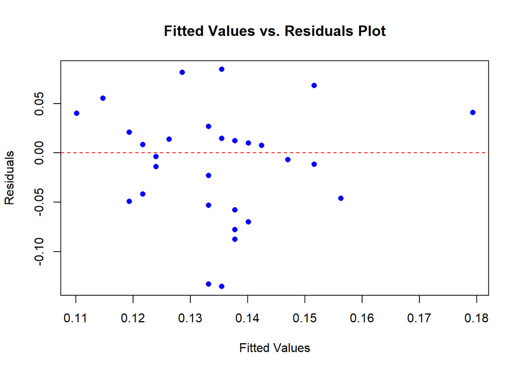

```r
plot(x = fitted(ideal_lm_model), y = resid(ideal_lm_model),
     xlab = "Fitted Values", ylab = "Residuals",
     main = "Fitted Values vs. Residuals Plot",
     pch = 16, col = "blue")
abline(h = 0, col = "red", lty = 2)
```

```r
summary(ideal_lm_model)
```

```
##
## Call:
## lm(formula = adwg ~ recruit_weight, data = ideal_data)
##
## Residuals:
##       Min        1Q    Median        3Q       Max
## -0.135481 -0.041636  0.008364  0.025288  0.084519
##
## Coefficients:
##                Estimate Std. Error t value Pr(>|t|)
## (Intercept)    0.045486   0.017395   2.615  0.00943 **
## recruit_weight 0.004615   0.000885   5.215 3.68e-07 ***
## ---
## Signif. codes:  0 '***' 0.001 '**' 0.01 '*' 0.05 '.' 0.1 ' ' 1
##
## Residual standard error: 0.0456 on 268 degrees of freedom
## Multiple R-squared:  0.09212,    Adjusted R-squared:  0.08874
## F-statistic: 27.19 on 1 and 268 DF,  p-value: 3.684e-07
```

p-value is small, it indicates strong evidence against the null hypothesis. In this case, the p-value is much smaller than the commonly used significance level of 0.05 (or 5%). Therefore, we have strong evidence to reject the null hypothesis that recruit weight has no influence on growth rate

# Find estimated coefficients obtained from the linear regression model

```r
exp(cbind(cc= coef(ideal_lm_model), confint(ideal_lm_model)))
```

```
##                      cc    2.5 %   97.5 %
## (Intercept)    1.046536 1.011300 1.082999
## recruit_weight 1.004626 1.002877 1.006378
```

# Multiple linear regression

We’ll use the marketing data set [datarium package], which contains the impact of the amount of money spent on three advertising medias (youtube, facebook and newspaper) on sales.

```r
library(tidyverse)
data("marketing", package = "datarium")
head(marketing, 4)
```

```
##   youtube facebook newspaper sales
## 1  276.12    45.36     83.04 26.52
## 2   53.40    47.16     54.12 12.48
## 3   20.64    55.08     83.16 11.16
## 4  181.80    49.56     70.20 22.20
```

# model

```r
model <- lm(sales ~ youtube + facebook+ newspaper ,data = marketing)

summary(model)
```

```
##
## Call:
## lm(formula = sales ~ youtube + facebook + newspaper, data = marketing)
##
## Residuals:
##      Min       1Q   Median       3Q      Max
## -10.5932  -1.0690   0.2902   1.4272   3.3951
##
## Coefficients:
##              Estimate Std. Error t value Pr(>|t|)
## (Intercept)  3.526667   0.374290   9.422   <2e-16 ***
## youtube      0.045765   0.001395  32.809   <2e-16 ***
## facebook     0.188530   0.008611  21.893   <2e-16 ***
## newspaper   -0.001037   0.005871  -0.177     0.86
## ---
## Signif. codes:  0 '***' 0.001 '**' 0.01 '*' 0.05 '.' 0.1 ' ' 1
##
## Residual standard error: 2.023 on 196 degrees of freedom
## Multiple R-squared:  0.8972, Adjusted R-squared:  0.8956
## F-statistic: 570.3 on 3 and 196 DF,  p-value: < 2.2e-16
```

**Interpretation**

p-value:

1. **YouTube coefficient**:
   - The p-value associated with the YouTube coefficient is <2e-16, which is essentially zero. This suggests strong evidence against the null hypothesis, indicating that the coefficient for YouTube is significantly different from zero. Therefore, there is a significant relationship between the YouTube advertising budget and sales.
2. **Facebook coefficient**:
   - The p-value associated with the Facebook coefficient is <2e-16, which is essentially zero. This suggests strong evidence against the null hypothesis, indicating that the coefficient for Facebook is significantly different from zero. Therefore, there is a significant relationship between the Facebook advertising budget and sales.
3. **Newspaper coefficient**:
   - The p-value associated with the newspaper coefficient is 0.86, which is much greater than the typical significance level of 0.05. This suggests that there is not enough evidence to reject the null hypothesis. Therefore, we fail to find a significant relationship between the newspaper advertising budget and sales based on this model.

R-squared: The multiple R-squared value of 0.8972 indicates that approximately 89.72% of the variability in sales can be explained by the independent variables (YouTube, Facebook, and newspaper advertising budgets) in the model.

```r
exp(cbind(cc= coef(model), confint(model)))
```

```
##                    cc      2.5 %    97.5 %
## (Intercept) 34.010430 16.2568561 71.152094
## youtube      1.046828  1.0439522  1.049712
## facebook     1.207473  1.1871405  1.228154
## newspaper    0.998963  0.9874633  1.010597
```